# 1. KNN 개념

: 주변 k개의 자료의 클래스 중 가장 많은 클래스로 특정 자료의 클래스르 지정하는 방법 (투표(voting)방식)

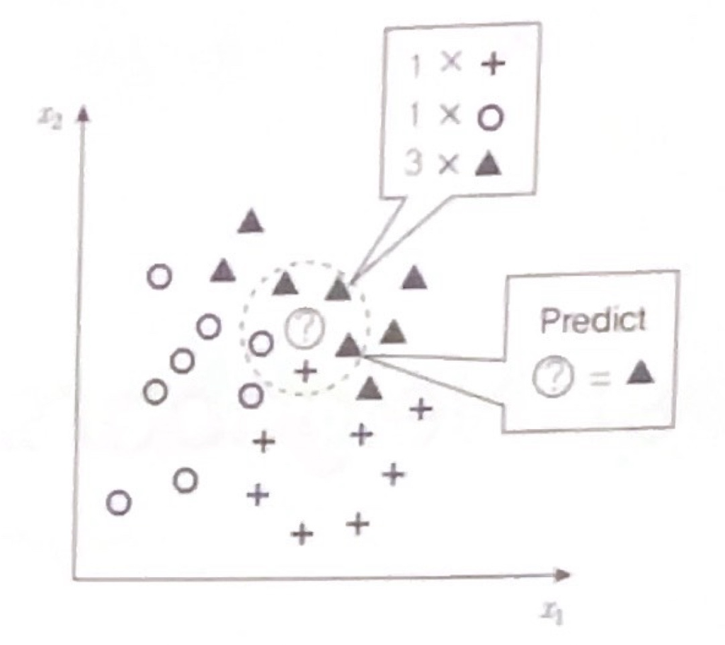

```python
from IPython.display import Image
image_path = 'C:/Users/MijinJ/OneDrive - 경북대학교/바탕 화면/jupyter사진/KNN1.jpg'
Image(filename=image_path, width=260)
```

두개의 특성변수($X_{1}$과 $X_{2}$)와 3개의 클래스를 가지고 있는 학습데이터  
k=5인 상황  
원안에 세모 클래스인 자료가 가장 많으므로 ?자료는 세모 클래스로 분류.

#### 따라서 KNN에서는 k와 거리측정방법(측도, metric)만 결정하면 된다

어떠한 추정방법도 없음. 새 자료의 클래스 분류를 위한 통계적 모형이나 자료변환도 필요 없다.  
학습데이터 자체만 있으면 됨. 이 때문에 KNN을 사례중심학습이라고도 부른다.

- KNN의 장점 매우 간단하지만서도 성능이 다른 분류기법에 뒤처지지 않음
- KNN의 단점 특성변수의 개수가 증가하면(차원이 증가하면) 차원의 저주 문제가 발생한다.

Minkowski거리($d(\mathbf{x}_{i}, \mathbf{x}_{j})=\sqrt[p]{\sum_{k=1}^{d}|x_{ik}-x_{jk}|^{p}}$)를 이용하여 k개의 근접치를 구하는게 보편적

# 2. KNN의 적용

iris데이터를 사용

```python
import seaborn as sns    #iris데이터가 seaborn라이브러리에 있음
iris=sns.load_dataset('iris')
print(iris.head())
```

```
   sepal_length  sepal_width  petal_length  petal_width species
0           5.1          3.5           1.4          0.2  setosa
1           4.9          3.0           1.4          0.2  setosa
2           4.7          3.2           1.3          0.2  setosa
3           4.6          3.1           1.5          0.2  setosa
4           5.0          3.6           1.4          0.2  setosa
```

히스토그램과 산포도로 데이터 확인

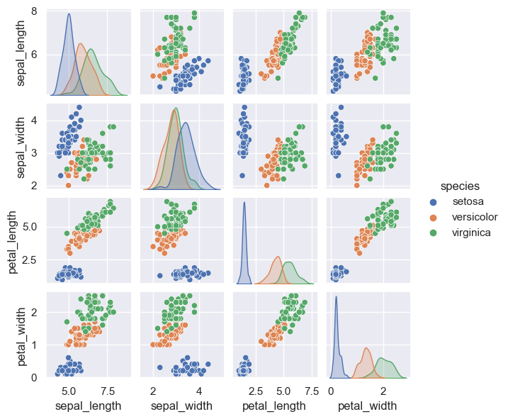

```python
sns.set()   #seaborn sytle로 그림 그릴 것.
sns.pairplot(iris, hue='species', height=1.5)   #species에 따라 클래스 나눔. height로 그림 크기 조정
```

```python
print(iris.shape)
```

```
(150, 5)
```

해당 데이터는 150개의 관측데이터와 5개의 변수를 가지고 있다. 아래와 같이 전처리를 거친다

```python
X=iris.drop('species', axis=1)   ##species변수를 제외한 변수들을 특성변수로 정의
y=iris['species']                ##species변수를 목적변수로 정의

#목적변수 species를 label encoding
from sklearn.preprocessing import LabelEncoder
classle=LabelEncoder()
y=classle.fit_transform(iris['species'].values)

#학습데이터와 시험 데이터를 7:3(testsize=0.3)으로 층화추출
from sklearn.model_selection import train_test_split
X_train, X_test, y_train, y_test=train_test_split(X,y,test_size=0.3, random_state=1, stratify=y)
```

KNN을 적용한다. KNeighborsClassifier를 호출한다.  
관측치 간의 거리는 p=2, k=5인 minkowski거리를 사용하는 KNN으로 객체화 한다.

```python
from sklearn.neighbors import KNeighborsClassifier
knn=KNeighborsClassifier(n_neighbors=5, p=2)    #KNN모델 객체화
knn.fit(X_train, y_train)                       #객체화 한 KNN모델을 학습데이터로 학습시킨다.
```

```
KNeighborsClassifier()
```

```python
y_train_pred=knn.predict(X_train)
y_test_pred=knn.predict(X_test)
print('# of traning samples:', len(y_train))
print('Misclassified training samples: %d' %(y_train!=y_train_pred).sum())
print('# of test samples:', len(y_test))
print('Misclassified test samples: %d' %(y_test!=y_test_pred).sum())
```

```
# of traning samples: 105
Misclassified training samples: 2
# of test samples: 45
Misclassified test samples: 1
```

학습데이터에서는 총 105개의 자료 중 2개가 잘못 분류되었고, 시험데이터에서는 45개의 자료 중 1개가 잘못 분류되었다.

sklearn의 accuracy_score를 이용해 정확도를 계산

```python
from sklearn.metrics import accuracy_score
print(accuracy_score(y_test, y_test_pred))
```

```
0.9777777777777777
```

sklearn의 confusion_matrix를 이용해 참값과 예측값 비교

```python
from sklearn.metrics import confusion_matrix
conf=confusion_matrix(y_true=y_test, y_pred=y_test_pred)
print(conf)
```

```
[[15  0  0]
 [ 0 15  0]
 [ 0  1 14]]
```

행은 참값, 열은 예측값. 따라서 setosa(0)과 versicolor(1)는 모두 정확히 분류되었고, virginica(2)는 15개 중 1개가 versicolor로 오분류 되었다.

### KNeighborsClassifier 대신 KNeighborsRegression 클래스를 호출하여 KNN회귀도 가능하다